# Introduction to mispitools

Franco L. Marsico

2026-08-26

## Overview

The **mispitools** package provides tools for missing person identification combining genetic and non-genetic evidence within a Bayesian framework. It implements likelihood ratio (LR) calculations for various types of evidence commonly used in forensic identification.

### Key Features

- **Genetic LR simulations**: Simulate likelihood ratios from DNA profiles using pedigree-based kinship analysis
- **Non-genetic LR calculations**: Compute LRs for sex, age, hair color, and birthdate evidence
- **Decision analysis**: Evaluate error rates and optimal thresholds
- **Visualization**: Plot LR distributions, decision curves, and CPT heatmaps
- **Interactive exploration**: Shiny apps for parameter exploration

## Installation

```r
# Install from CRAN (when available)
install.packages("mispitools")

# Or install the development version from GitHub
# devtools::install_github("MarsicoFL/mispitools")
```

## The Bayesian Framework

In missing person identification, we compare two hypotheses:

- **H1**: The person of interest (POI) is the missing person (MP)
- **H2**: The POI is unrelated to the MP

The **likelihood ratio (LR)** quantifies the relative support for H1 vs H2:

$$LR = \frac{P(Evidence | H1)}{P(Evidence
| H2)}$$

Multiple pieces of evidence can be combined by multiplying their LRs:

$$LR_{total} = LR_{genetic} \times
LR_{sex} \times LR_{age} \times LR_{color}$$

## Quick Start

### Non-Genetic Evidence

Calculate the LR for sex evidence when the missing person is female:

```r
library(mispitools)

# LR for sex evidence
# H1: MP is female, POI observed as female
# eps = probability of sex observation error
lr_sex(LR = TRUE, H = 1, eps = 0.05)
```

```
#> lr_sex() is soft-deprecated in mispitools 2.0 and will be removed after the 2.0 release cycle. Use nongenetic_feature(type = "sex", ...) with the per-feature engine.
#> Suppress this notice with options(mispitools.suppress_deprecation = TRUE).
#>      Sexo LRs
#> 1       F 1.9
#> 2       F 1.9
#> 3       F 1.9
#> 4       F 1.9
#> 5       F 1.9
#> 6       F 1.9
#> 7       F 1.9
#> 8       F 1.9
#> 9       F 1.9
#> 10      F 1.9
#> 11      F 1.9
#> 12      F 1.9
```

[output cut: 988 more lines]

Calculate the LR for age evidence:

```r
# LR for age evidence
# MP age = 25, tolerance range = 5 years
# POI observed age falls within range
lr_age(LR = TRUE, H = 1, MPa = 25, MPr = 5, epa = 0.05)
```

```
#> lr_age() is soft-deprecated in mispitools 2.0 and will be removed after the 2.0 release cycle. Use nongenetic_feature(type = "age", ...) with the per-feature engine.
#> Suppress this notice with options(mispitools.suppress_deprecation = TRUE).
#>      group Age UHRmin UHRmax        LRa
#> 1       T1  30  26.90  33.10 7.60000000
#> 2       T1  22  19.46  24.54 7.60000000
#> 3       T1  25  22.25  27.75 7.60000000
#> 4       T1  21  18.53  23.47 7.60000000
#> 5       T1  30  26.90  33.10 7.60000000
#> 6       T1  21  18.53  23.47 7.60000000
#> 7       T1  23  20.39  25.61 7.60000000
#> 8       T1  21  18.53  23.47 7.60000000
#> 9       T1  27  24.11  29.89 7.60000000
#> 10      T1  28  25.04  30.96 7.60000000
#> 11      T1  26  23.18  28.82 7.60000000
#> 12      T1  20  17.60  22.40 7.60000000
```

[output cut: 988 more lines]

### Conditional Probability Tables

The package uses Conditional Probability Tables (CPTs) to model evidence under each hypothesis:

```r
# CPT under H2 (population hypothesis)
cpt_h2 <- cpt_population(
  propS = c(0.5, 0.5),  # 50% female, 50% male
  MPa = 30,             # MP age
  MPr = 5,              # Age range
  propC = c(0.3, 0.25, 0.2, 0.15, 0.1)  # Hair color proportions
)
```

```
#> cpt_population() is soft-deprecated in mispitools 2.0 and will be removed after the 2.0 release cycle. Use nongenetic_feature() per feature with the per-feature engine.
#> Suppress this notice with options(mispitools.suppress_deprecation = TRUE).
```

```r
# CPT under H1 (MP hypothesis)
cpt_h1 <- cpt_missing_person(
  MPs = 1,    # Female
  MPc = 2,    # Hair color 2
  eps = 0.05, # Sex error
  epa = 0.05, # Age error
  epc = error_matrix_hair()  # Hair color error matrix
)
```

```
#> cpt_missing_person() is soft-deprecated in mispitools 2.0 and will be removed after the 2.0 release cycle. Use nongenetic_feature() per feature with the per-feature engine.
#> Suppress this notice with options(mispitools.suppress_deprecation = TRUE).
```

```r
# View dimensions
dim(cpt_h1)
```

```
#> [1] 4 5
```

### Visualizing CPTs

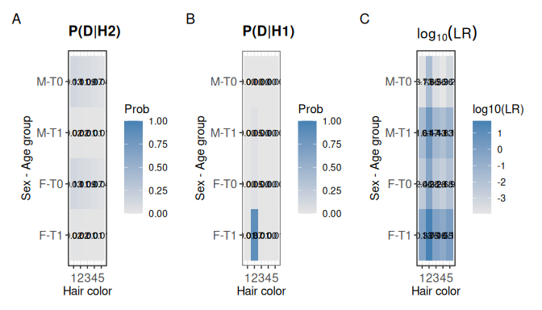

```r
# Visualize both CPTs and LR heatmap
plot_cpt(cpt_h2, cpt_h1)
```

## Available Functions

### LR Calculation Functions

| Function | Description |
| --- | --- |
| `lr_sex()` | LR for biological sex evidence |
| `lr_age()` | LR for age evidence |
| `lr_hair_color()` | LR for hair color evidence |
| `lr_birthdate()` | LR for birthdate evidence (Dirichlet model) |
| `lr_pigmentation()` | LR for multiple pigmentation traits |

### Simulation Functions

| Function | Description |
| --- | --- |
| `sim_lr_genetic()` | Simulate genetic LRs from pedigrees |
| `sim_lr_prelim()` | Simulate non-genetic LRs |
| `sim_poi_prelim()` | Generate random non-genetic data |

### Decision Analysis

| Function | Description |
| --- | --- |
| `decision_threshold()` | Find optimal LR threshold |
| `threshold_rates()` | Calculate TPR/FPR at different thresholds |
| `lr_combine()` | Combine genetic and non-genetic LRs |

### Visualization

| Function | Description |
| --- | --- |
| `plot_lr_distribution()` | Plot LR distributions under H1/H2 |
| `plot_decision_curve()` | ROC-like decision curves |
| `plot_cpt()` | Heatmap of CPT values |

### Interactive Apps

Launch interactive Shiny applications:

```r
# Basic CPT explorer
app_mispitools()

# Advanced LR comparison with ROC analysis
app_lr_comparison()
```

## Population Frequency Databases

The package includes allele frequency databases for genetic LR calculations:

```r
# Available databases
data(Argentina)
data(Europe)
data(USA)
data(Asia)
data(Austria)
data(BosniaHerz)
data(China)
data(Japan)

# View structure
dim(Argentina)
```

```
#> [1] 93 25
```

```r
names(Argentina)[1:10]
```

```
#>  [1] "Allele"  "D8S1179" "D21S11"  "D7S820"  "CSF1PO"  "D3S1358" "THO1"
#>  [8] "D13S317" "D16S539" "D2S1338"
```

## Next Steps

See the “Complete Workflow” vignette for a full example combining genetic and non-genetic evidence in a missing person case.

## References

Marsico FL, Vigeland MD, Egeland T, Herrera Pinero F (2021). “Making decisions in missing person identification cases with low statistical power.” *Forensic Science International: Genetics*, 52, 102519. https://doi.org/10.1016/j.fsigen.2021.102519

Marsico FL, et al. (2023). “Likelihood ratios for non-genetic evidence in missing person cases.” *Forensic Science International: Genetics*, 66, 102891. https://doi.org/10.1016/j.fsigen.2023.102891